# Projet Econométrie 2024

SCHNEIDER Hugo CARPENTIER Lola CORBARI Ugo

2024-12-12

## 1 Données et visualisation

Ici, l’indicateur de la performance des équipes sera le nombre de points totaux obtenus par saison en Formule 1 sur la période étudiée. Ces données proviennent du site officiel “Formula 1”.

Concernant les budgets annuels des écuries, exprimés en millions d’euros, ces derniers regroupent tous les coûts liés aux performances des voitures et sont issus de Sportune.

L’intuition derrière le lien entre le budget et la performance est que plus une équipe peut dépenser pour sa voiture, plus cette dernière sera performante. De plus, l’écurie avec un grand budget sera plus à même de verser des salaires importants pour attirer les meilleurs ingénieurs.

En guise de variables de contrôle, nous avons ajouté des variables liées au nombre de poles positions par an et par écurie, ainsi qu’une variable recensant le temps moyen d’arrêt aux stands par écurie et par saison. Dans notre régression, nous avons aussi ajouté des variables permettant de recenser le nombre de spectateurs moyens par course au cours de la saison, mais aussi une variable recensant le nombre d’employés des écuries par saison.

Ci-dessous vous trouverez un extrait de la base de donnée que nous avons utilisés;

```
## # A tibble: 98 × 8
##    Team      Year Points Budget  Pole  Time Salariés Specs
##    <chr>    <dbl>  <dbl>  <dbl> <dbl> <dbl>    <dbl> <dbl>
##  1 Mercedes  2010    214    180     0   4.2      800   3
##  2 Mercedes  2011    165    180     0   3.6      850   3.1
##  3 Mercedes  2012    142    180     1   3.3      900   3.2
##  4 Mercedes  2013    360    210     8   3.1      950   3.3
##  5 Mercedes  2014    701    320    18   2.9     1000   3.5
##  6 Mercedes  2015    703    470    18   2.8     1050   3.6
##  7 Mercedes  2016    765    305    20   2.7     1100   3.7
##  8 Mercedes  2017    668    470    15   2.6     1150   3.8
##  9 Mercedes  2018    655    400    13   2.4     1200   4
## 10 Mercedes  2019    739    485    10   2.2     1250   4.2
## # ℹ 88 more rows
```

## Statistiques descriptives

Il s’agit à présent de visualiser les données que nous allons utiliser pour la regression :

```
##      Team                Year          Points          Budget
##  Length:98          Min.   :2010   Min.   :  0.0   Min.   : 70.0
##  Class :character   1st Qu.:2013   1st Qu.: 44.0   1st Qu.:141.5
##  Mode  :character   Median :2016   Median :157.0   Median :177.5
##                     Mean   :2016   Mean   :240.5   Mean   :225.2
##                     3rd Qu.:2019   3rd Qu.:414.0   3rd Qu.:270.0
##                     Max.   :2022   Max.   :765.0   Max.   :535.0
##       Pole             Time          Salariés          Specs
##  Min.   : 0.000   Min.   :2.000   Min.   : 250.0   Min.   :0.300
##  1st Qu.: 0.000   1st Qu.:2.700   1st Qu.: 585.0   1st Qu.:3.100
##  Median : 0.000   Median :3.200   Median : 750.0   Median :3.500
##  Mean   : 2.561   Mean   :3.177   Mean   : 773.2   Mean   :3.301
##  3rd Qu.: 2.000   3rd Qu.:3.600   3rd Qu.: 950.0   3rd Qu.:3.800
##  Max.   :20.000   Max.   :4.700   Max.   :1300.0   Max.   :4.500
```

Les statistiques descriptives du jeu de données montrent des informations sur plusieurs variables pour les équipes de Formule 1 au cours des années 2010 à 2022. Le nombre de points varie de 0 à 765, avec une moyenne de 240,5 et une médiane de 157, ce qui indique des performances très disparates entre les équipes. Le budget des équipes s’étend de 70 millions à 535 millions, avec une moyenne de 225,2 millions et une médiane de 177,5 millions.

En ce qui concerne le temps moyen passé par les pilotes aux stands durant une saison, il varie de 2 à 4,7, avec une moyenne de 3,18 et une médiane de 3,2. Le nombre d’employés des équipes va de 250 à 1300, avec une moyenne de 773,2 et une médiane de 750. Ces données permettent d’analyser la distribution et les tendances des différentes variables liées aux équipes de Formule 1 pendant la période étudiée.

## Relation entre nos variables

Nous pouvons ainsi réaliser un graphique pour lier nos principales variables entre elles afin de visualiser les dynamiques entre les variables budget et points obtenus.

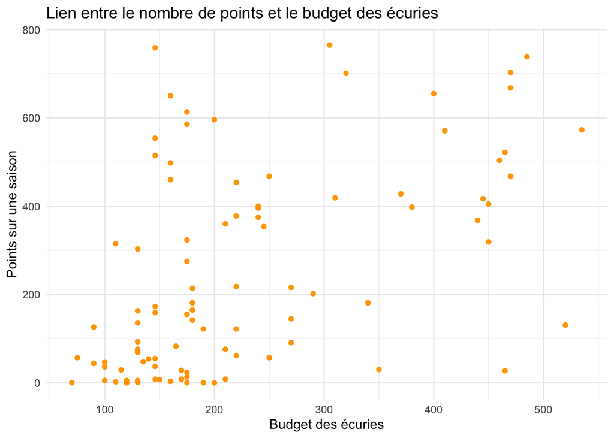

Graphiquement, il semble que l’on puisse tirer quelques premières conclusions. Tout d’abord, il apparaît que les écuries avec un budget inférieur ou égal à 100 millions d’euros ne dépassent que très rarement les 125 points. Le second enseignement intéressant de ce graphique est qu’entre 150 et 200 millions d’euros de budget, la dispersion du nombre de points est la plus importante. En d’autres termes, à budget similaire, certaines écuries vont engranger (beaucoup) plus de points que d’autres. D’autres part les observations sont très dispersées et hétérogènes ce qui indique que le budget des écuries n’explique pas à lui seul les performances.

## 2 Création et tests sur les modèles

Nous créons maintenant les modèles qui nous intéressent afin d’appréhender la relation entre nos variables. Dans un premier temps nous créons un modèle de moindres carrés ordinaires (MCO) simple entre nos deux variables, ce modèle se présente de la sorte et servira de base de comparaisons :

Points = ß0 + ß1xLog(Budget) + ei

Nous établissont on deuxième modèle MCO dans lequel nous ajoutons les variables de contôle suvantes : le nombre de salariés de l’écurie, le nombre de poles positions, le temps moyen passé au stands par saisons, et le nombre de spectateurs. Le modèle se présente de la sorte :

Points = ß0 + ß1xLog(Budget) + ß2xSalariés + ß3xPole + ß4xTime+ ß5xSpecs + ei

```
##
## =================================================================
##                                  Dependent variable:
##                     ---------------------------------------------
##                                        Points
##                              (1)                    (2)
## -----------------------------------------------------------------
## log(Budget)               248.055***               31.246
##                            (40.194)               (34.264)
##
## Salariés                                          0.334***
##                                                   (0.063)
##
## Pole                                             27.718***
##                                                   (2.416)
##
## Time                                               19.148
##                                                   (23.763)
##
## Specs                                              16.412
##                                                   (10.993)
##
## Constant                -1,072.017***            -368.965*
##                           (213.593)              (215.457)
##
## -----------------------------------------------------------------
## Observations                  98                     98
## R2                          0.284                  0.791
## Adjusted R2                 0.277                  0.780
## Residual Std. Error   196.080 (df = 96)      108.237 (df = 92)
## F Statistic         38.087*** (df = 1; 96) 69.610*** (df = 5; 92)
## =================================================================
## Note:                                 *p<0.1; **p<0.05; ***p<0.01
```

Les résultats des modèles mettent en lumière des différences importantes dans les relations entre les variables étudiées. Le t-test montre que certaines variables explicatives ont une influence statistiquement significative sur les points obtenus par les équipes. Par exemple, le nombre de salariés (p < 0,01) et le nombre de poles (p < 0,01) sont fortement associés au nombre de points, tandis que d’autres comme le temps passé dans les stands et le nombre de spectateurs ne montrent pas de significativité.

Le F-test, qui mesure la qualité globale du modèle, est significatif dans les deux cas (p < 0,01), indiquant que les modèles expliquent une proportion significative de la variance des points. Cela confirme que les variables explicatives prises ensemble apportent une information pertinente.

Concernant le R², le premier modèle basé uniquement sur le budget a un R² de 0,284, ce qui signifie qu’environ 28,4 % de la variance des points est expliquée. En revanche, le modèle intégrant plusieurs variables explicatives (salariés, poles, temps, spécifications) améliore considérablement ce chiffre avec un R² de 0,791. Cela indique que ce dernier modèle capture beaucoup mieux les dynamiques complexes influençant les performances des équipes.

Enfin avant d’analyser les implications de ce modèle nous réalisons les tests d’homoscédasticité et d’autocorrélation.

```
##
##  studentized Breusch-Pagan test
##
## data:  MCO
## BP = 1.5913, df = 1, p-value = 0.2071
```

```
##
##  studentized Breusch-Pagan test
##
## data:  MCO2
## BP = 5.3757, df = 5, p-value = 0.3718
```

Les tests de Breusch-Pagan indiquent des statistiques de tests avec des p-values largement supérieures au seuil habituel de 0,05, ce qui nous conduit à accepter l’hypothèse nulle d’homoscédasticité. Ainsi, aucun de nos deux modèles ne présente d’hétéroscédasticité des résidus.

Testons à présent si nos modèles présentent de l’autocorrélation des résidus à l’aide du test de Durbin-Watson :

```
##
##  Durbin-Watson test
##
## data:  MCO
## DW = 0.72993, p-value = 2.742e-13
## alternative hypothesis: true autocorrelation is greater than 0
```

```
##
##  Durbin-Watson test
##
## data:  MCO2
## DW = 0.7644, p-value = 5.491e-13
## alternative hypothesis: true autocorrelation is greater than 0
```

Les tests de Durbin-Watson indiquent des statistiques de test inférieur à 2 ainsi nos deux modèles présentent de l’auto-corrélation des résidus.

Nous devons alors corriger l’autocorrelation afin de pouvoir analyser les implications de nos modèles, il faut noter que la présence d’autocorrélation de typte 1 était prévisible puisque nos données sont temporelles. Ainsi pour corriger l’autocorrélation nous allons mettre en place un modèle de moindres carrés généralisés GLS :

```
##
## ===============================================================================
##                                         Dependent variable:
##                     -----------------------------------------------------------
##                                               Points
##                                          OLS                       generalized
##                                                                   least squares
##                              (1)                    (2)                (3)
## -------------------------------------------------------------------------------
## log(Budget)               248.055***               31.246            -31.679
##                            (40.194)               (34.264)          (27.896)
##
## Salariés                                          0.334***          0.485***
##                                                   (0.063)            (0.115)
##
## Pole                                             27.718***          23.187***
##                                                   (2.416)            (2.671)
##
## Time                                               19.148            48.008
##                                                   (23.763)          (35.506)
##
## Specs                                              16.412           15.253**
##                                                   (10.993)           (6.732)
##
## Constant                -1,072.017***            -368.965*          -223.975
##                           (213.593)              (215.457)          (227.557)
##
## -------------------------------------------------------------------------------
## Observations                  98                     98                98
## R2                          0.284                  0.791
## Adjusted R2                 0.277                  0.780
## Log Likelihood                                                      -551.622
## Akaike Inf. Crit.                                                   1,119.243
## Bayesian Inf. Crit.                                                 1,139.418
## Residual Std. Error   196.080 (df = 96)      108.237 (df = 92)
## F Statistic         38.087*** (df = 1; 96) 69.610*** (df = 5; 92)
## ===============================================================================
## Note:                                               *p<0.1; **p<0.05; ***p<0.01
```

Le modèle GLS présente-il de l’auto-corrélation ?

```
##
##  Durbin-Watson test
##
## data:  lm_residuals
## DW = 0.6615, p-value = 9.902e-15
## alternative hypothesis: true autocorrelation is greater than 0
```

Le test de Durbin-Watson effectué sur les résidus du modèle donne une statistique DW de 0,6615 avec une p-value extrêmement faible (9,902e-15). Cela indique qu’il existe une forte autocorrélation positive des résidus, et nous rejetons donc l’hypothèse nulle d’absence d’autocorrélation. Ce résultat suggère que le modèle viole l’hypothèse fondamentale d’indépendance des résidus, ce qui pourrait biaiser les estimations et compromettre leur validité.

## 3 interpretation

Les résultats des modèles indiquent que le nombre de salariés et les pole positions sont les principaux déterminants du nombre de points obtenus par les équipes de Formule 1. Ces deux variables sont fortement significatives (p < 0,01) dans les deux approches (GLS et OLS), confirmant leur impact positif. En revanche, ni le budget (ou son logarithme) ni le temps moyen passé aux stands ne montrent d’effet significatif sur les performances en points, suggérant que leur influence pourrait être indirecte ou dépendre d’autres facteurs. Le modèle OLS affiche un R² ajusté élevé de 0,779, indiquant que près de 78 % de la variance des points est expliquée par les variables incluses. La statistique F (p < 0,01) confirme la significativité globale du modèle. Ces résultats mettent en lumière l’importance des ressources humaines et des performances stratégiques (pole positions) pour expliquer les succès des équipes, tandis que l’effet direct du budget mérite des analyses supplémentaires.

## Conclusion

Les résultats de notre étude ont montré qu’il n’existait pas de relation significative entre le budget des écuries et leur nombre de points. De plus, notre analyse présente une limite importante liée à un problème d’autocorrélation, qui a persisté malgré nos tentatives de correction et les tests effectués. Par ailleurs, nous avons également rencontré d’autres limites, notamment l’accès restreint à certaines données confidentielles, telles que les mises à jour aérodynamiques ou le nombre exact d’ingénieurs par écurie, ce qui aurait pu enrichir notre étude.